# Feature_Selection_Model_Tuning_Tiffany_Chan

## 2. Bi-variate analysis between the predictor variables and between the predictor variables and target column. Comment on your findings in terms of their relationship and degree of relation if any. Visualize the analysis using boxplots and pair plots, histograms, or density curves. (10 marks)

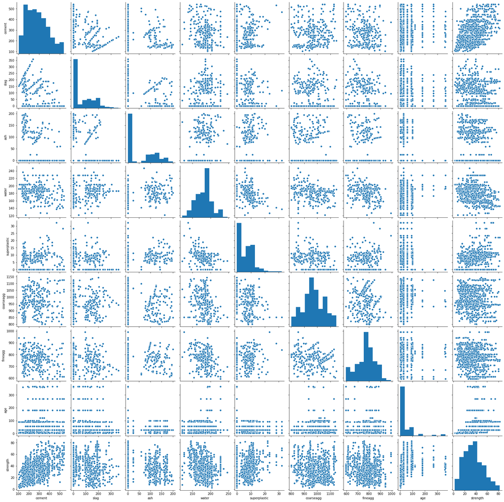

```python
sns.pairplot(conc);
```

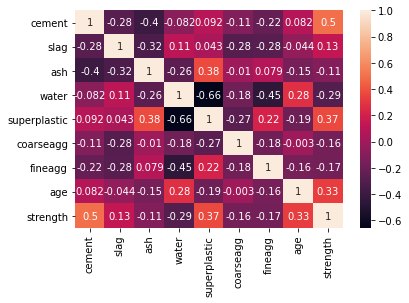

```python
sns.heatmap(conc.corr(), annot = True);
```

After evaluating Pearson's correlation matrix for the variables, there are oly 2 relationships that are moderately correlated.

1. Water and superplastic are inversely correlated. Pearson's correlation: -0.66, suggesting that an increase of water amount is paired with a decrease in superplasticizer, and vice versa. However, this correlation is not that strong and should not be taken too seriously.
2. Cement and strength (outcome variable) are also moderately correlated. Pearson's correlation: 0.5, meaning that as the cement amount goes up, the strength also goes up. Like the previous observation, this correlation relationship is only moderate and should not be taken too seriously.
3. Every other relationship seems to be very weakly correlated.

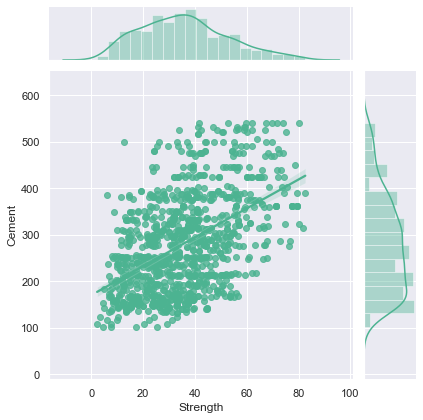

```python
#Visualizing bivariate analysis of 2 continuous variables (One is an independent variable, and the other is the dependent target variable)
#Strength is the target variable of out analysis.

#Cement x strength
conc_cem_strength = sns.jointplot(x = 'strength', y = 'cement', data = conc, kind = 'reg', color="#4CB391")
conc_cem_strength.set_axis_labels(xlabel='Strength', ylabel='Cement')
```

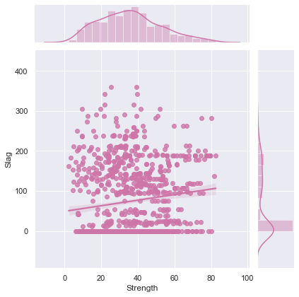

```python
#Slag x Strength
conc_slag_strength = sns.jointplot(x = 'strength', y = 'slag', data = conc, kind = 'reg', color="#CE75A7")
conc_slag_strength.set_axis_labels(xlabel='Strength', ylabel='Slag')
```

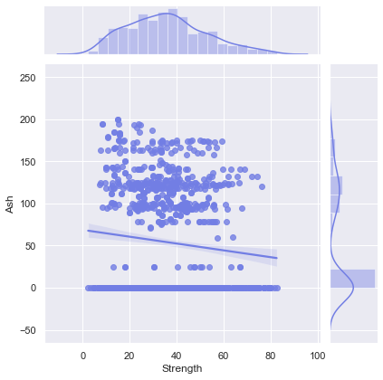

```python
#Ash x Strength
conc_ash_strength = sns.jointplot(x = 'strength', y = 'ash', data = conc, kind = 'reg', color="#727ee4")
conc_ash_strength.set_axis_labels(xlabel='Strength', ylabel='Ash')
```

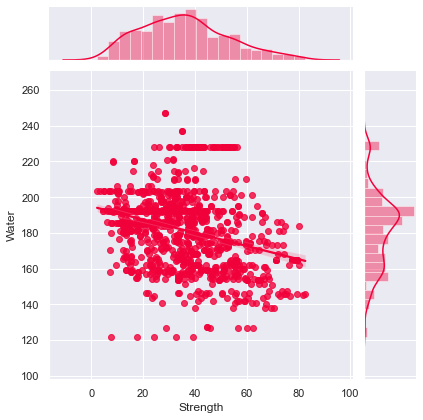

```python
#Water x Strength
conc_water_strength = sns.jointplot(x = 'strength', y = 'water', data = conc, kind = 'reg', color="#f2013a")
conc_water_strength.set_axis_labels(xlabel='Strength', ylabel='Water')
```

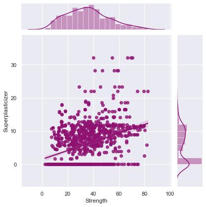

```python
#Superplasticizer x Strength
conc_super_strength = sns.jointplot(x = 'strength', y = 'superplastic', data = conc, kind = 'reg', color="#8f1271")
conc_super_strength.set_axis_labels(xlabel='Strength', ylabel='Superplasticizer')
```

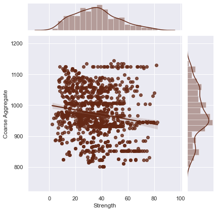

```python
#Coarse Aggregate x Strength
conc_coarseagg_strength = sns.jointplot(x = 'strength', y = 'coarseagg', data = conc, kind = 'reg', color="#642815")
conc_coarseagg_strength.set_axis_labels(xlabel='Strength', ylabel='Coarse Aggregate')
```

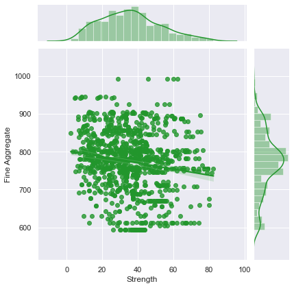

```python
#Fine Aggregate x Strength
conc_fineagg_strength = sns.jointplot(x = 'strength', y = 'fineagg', data = conc, kind = 'reg', color="#22962c")
conc_fineagg_strength.set_axis_labels(xlabel='Strength', ylabel='Fine Aggregate')
```

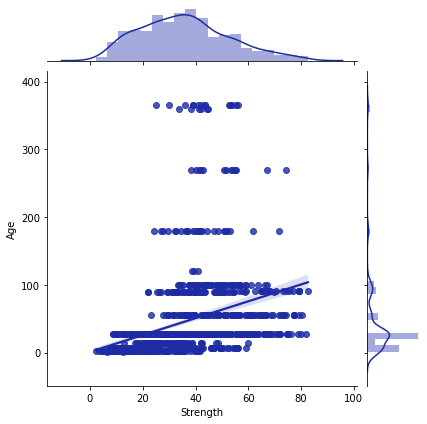

```python
#Age x Strength
conc_age_strength = sns.jointplot(x = 'strength', y = 'age', data = conc, kind = 'reg', color="#1d2ba5")
conc_age_strength.set_axis_labels(xlabel='Strength', ylabel='Age')
```

None of the variables seem to fit perfectly on a straight line. However, you never know. It would still be worth it to see how linear regression peforms on this dataset.

## 3. Feature Engineering techniques(10 marks)

## -Identify opportunities (if any) to extract new features from existing features, drop a feature(if required) Hint: Feature Extraction, for example, consider a dataset with two features length and breadth. From this, we can extract a new feature Area which would be length * breadth.

## -Get the data model ready and do a train test split.

## -Decide on the complexity of the model, should it be a simple linear model in terms of parameters or would a quadratic or higher degree.

There are multiple opportunities to extract new features from existing features in this dataset. In certain cases,

1. Age can be re-categorized so that we can make a feature that may better generalize the test data. After researching on concrete, age can be broken down into unsatisfactory, minimum, standard, extra number of aging days.
2. When mixing aggregate (coarse aggregate or stone) with sand (fine aggregate), there is supposed to be a 2:1 ratio. We can create a new feature that captures the ratio between these two features.
3. There is also a water to cement ratio that exists and it should be 0.45-0.6. We can create another feature that captures the quatitifying relationship between these two features.
4. In terms of the superplasticizer, the percentage generally ranges from 0-7% of the entire mixture of all concrete components. Perhaps, we can create a new feature looking at this percentage in relation to the entire mixture in kg/m^3. Since all the predictor variables have the same units of measurement, we can easily calculate this.

```python
#New extracted feature from 'age': 'agedays'

#Finding mode for age to see if the data agrees with the literature online.
#The standard number of days it takes to make concrete according to literature is 28 days.
import statistics
print("Mode for age variable:")
print(statistics.mode(conc['age']))
#The mode shows that most of the cases in this dataset followed the standard number of concrete ageing days.
print("")
#Review the frequency of the other number of days.
print("Frequency for age variable:")
print(conc['age'].value_counts())

#After doing some research on how the number of days can improve compressive strength, I discovered 28 days is the arbitrary standard number of days.
#7 days equals 75% of concrete's compressive strength, which is considered the minumum accepted compressive strength.
#Less than 7 days, the strength is not satisfactory.
#More than 28 days allows for assured solidification.


#Re-categorizing 'age' and naming it 'agedays'
#conc['agedays'] = conc['age']
bins = [1, 6, 7, 27, 28, 365]
labels = ['1-6', '7', '8-27', '28', '29-365']
conc['agedays'] = pd.cut(conc.age, bins, labels = labels,include_lowest = True)
#Verifying the new categorized variable:
print(conc['agedays'].value_counts())
#Since this variable can be construed as ordinal, we can replace it with ordinval values
replaceStruct = {"agedays":     {"1-6": 1, "7": 2 ,"8-27": 3 , "28": 4, "29-365": 5}}
conc=conc.replace(replaceStruct)
conc.head(10)
```

```
Mode for age variable:
28

Frequency for age variable:
28     425
3      134
7      126
56      91
14      62
90      54
100     52
180     26
91      22
365     14
270     13
360      6
120      3
1        2
Name: age, dtype: int64
28        425
29-365    281
1-6       136
7         126
8-27       62
Name: agedays, dtype: int64
```

|  | cement | slag | ash | water | superplastic | coarseagg | fineagg | age | strength | agedays |
| --- | --- | --- | --- | --- | --- | --- | --- | --- | --- | --- |
| 0 | 141.3 | 212.0 | 0.0 | 203.5 | 0.0 | 971.8 | 748.5 | 28 | 29.89 | 4 |
| 1 | 168.9 | 42.2 | 124.3 | 158.3 | 10.8 | 1080.8 | 796.2 | 14 | 23.51 | 3 |
| 2 | 250.0 | 0.0 | 95.7 | 187.4 | 5.5 | 956.9 | 861.2 | 28 | 29.22 | 4 |
| 3 | 266.0 | 114.0 | 0.0 | 228.0 | 0.0 | 932.0 | 670.0 | 28 | 45.85 | 4 |
| 4 | 154.8 | 183.4 | 0.0 | 193.3 | 9.1 | 1047.4 | 696.7 | 28 | 18.29 | 4 |
| 5 | 255.0 | 0.0 | 0.0 | 192.0 | 0.0 | 889.8 | 945.0 | 90 | 21.86 | 5 |
| 6 | 166.8 | 250.2 | 0.0 | 203.5 | 0.0 | 975.6 | 692.6 | 7 | 15.75 | 2 |
| 7 | 251.4 | 0.0 | 118.3 | 188.5 | 6.4 | 1028.4 | 757.7 | 56 | 36.64 | 5 |
| 8 | 296.0 | 0.0 | 0.0 | 192.0 | 0.0 | 1085.0 | 765.0 | 28 | 21.65 | 4 |
| 9 | 155.0 | 184.0 | 143.0 | 194.0 | 9.0 | 880.0 | 699.0 | 28 | 28.99 | 4 |

```python
#Capturing the coarse aggregate to sand ratio. Standard cement:sand:agg ratio is 1:2:4. Dividing coarse aggregate by fine aggregate would normally result in 2.
conc['agg_sand_ratio'] = conc['coarseagg']/conc['fineagg'] # Standard should be 2. Between 1-2 suggests more rock than sand but not standard measurements. 1 means equal sand:rock measurement. Less than 1 suggests more sand to rock (normally for smaller delicate projects like making a fountain/)
conc.head(10)
```

|  | cement | slag | ash | water | superplastic | coarseagg | fineagg | age | strength | agedays | agg_sand_ratio |
| --- | --- | --- | --- | --- | --- | --- | --- | --- | --- | --- | --- |
| 0 | 141.3 | 212.0 | 0.0 | 203.5 | 0.0 | 971.8 | 748.5 | 28 | 29.89 | 4 | 1.298330 |
| 1 | 168.9 | 42.2 | 124.3 | 158.3 | 10.8 | 1080.8 | 796.2 | 14 | 23.51 | 3 | 1.357448 |
| 2 | 250.0 | 0.0 | 95.7 | 187.4 | 5.5 | 956.9 | 861.2 | 28 | 29.22 | 4 | 1.111124 |
| 3 | 266.0 | 114.0 | 0.0 | 228.0 | 0.0 | 932.0 | 670.0 | 28 | 45.85 | 4 | 1.391045 |
| 4 | 154.8 | 183.4 | 0.0 | 193.3 | 9.1 | 1047.4 | 696.7 | 28 | 18.29 | 4 | 1.503373 |
| 5 | 255.0 | 0.0 | 0.0 | 192.0 | 0.0 | 889.8 | 945.0 | 90 | 21.86 | 5 | 0.941587 |
| 6 | 166.8 | 250.2 | 0.0 | 203.5 | 0.0 | 975.6 | 692.6 | 7 | 15.75 | 2 | 1.408605 |
| 7 | 251.4 | 0.0 | 118.3 | 188.5 | 6.4 | 1028.4 | 757.7 | 56 | 36.64 | 5 | 1.357265 |
| 8 | 296.0 | 0.0 | 0.0 | 192.0 | 0.0 | 1085.0 | 765.0 | 28 | 21.65 | 4 | 1.418301 |
| 9 | 155.0 | 184.0 | 143.0 | 194.0 | 9.0 | 880.0 | 699.0 | 28 | 28.99 | 4 | 1.258941 |

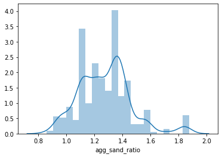

```python
#Visualizing the new feature using distplot
sns.distplot(conc['agg_sand_ratio']);
```

The distplot for the agg_sand_ratio suggests that most projects did not follow standard mixing amounts of coarse to fine aggregate. Most cases still had more rock than sand (Cases > 1.0). There are fewer cases where the rock:sand ratio is < 1; those are most likely small projects that require more sand in the mixture.

```python
#Water:Cement ratio
conc['water_cem_ratio'] = conc['water']/conc['cement']
conc.head(10)
```

|  | cement | slag | ash | water | superplastic | coarseagg | fineagg | age | strength | agedays | agg_sand_ratio | water_cem_ratio |
| --- | --- | --- | --- | --- | --- | --- | --- | --- | --- | --- | --- | --- |
| 0 | 141.3 | 212.0 | 0.0 | 203.5 | 0.0 | 971.8 | 748.5 | 28 | 29.89 | 4 | 1.298330 | 1.440198 |
| 1 | 168.9 | 42.2 | 124.3 | 158.3 | 10.8 | 1080.8 | 796.2 | 14 | 23.51 | 3 | 1.357448 | 0.937241 |
| 2 | 250.0 | 0.0 | 95.7 | 187.4 | 5.5 | 956.9 | 861.2 | 28 | 29.22 | 4 | 1.111124 | 0.749600 |
| 3 | 266.0 | 114.0 | 0.0 | 228.0 | 0.0 | 932.0 | 670.0 | 28 | 45.85 | 4 | 1.391045 | 0.857143 |
| 4 | 154.8 | 183.4 | 0.0 | 193.3 | 9.1 | 1047.4 | 696.7 | 28 | 18.29 | 4 | 1.503373 | 1.248708 |
| 5 | 255.0 | 0.0 | 0.0 | 192.0 | 0.0 | 889.8 | 945.0 | 90 | 21.86 | 5 | 0.941587 | 0.752941 |
| 6 | 166.8 | 250.2 | 0.0 | 203.5 | 0.0 | 975.6 | 692.6 | 7 | 15.75 | 2 | 1.408605 | 1.220024 |
| 7 | 251.4 | 0.0 | 118.3 | 188.5 | 6.4 | 1028.4 | 757.7 | 56 | 36.64 | 5 | 1.357265 | 0.749801 |
| 8 | 296.0 | 0.0 | 0.0 | 192.0 | 0.0 | 1085.0 | 765.0 | 28 | 21.65 | 4 | 1.418301 | 0.648649 |
| 9 | 155.0 | 184.0 | 143.0 | 194.0 | 9.0 | 880.0 | 699.0 | 28 | 28.99 | 4 | 1.258941 | 1.251613 |

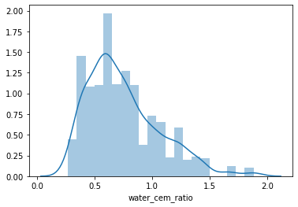

```python
#Visualizing water:cement ratio
sns.distplot(conc['water_cem_ratio']);
```

Normally, this value is around 0.45-0.6. This distplot seems to reflect that. There are a lot of cases that are crowding in this 0.46-0.6 range, suggesting a lot of the cases in this dataset did follow for the most part standard water:cement mixing.

Now we should try to take care of those outliers in the different variables. This is part of EDA and feature engineering.

```
Interquartile range:
27.099999999999994
75th percentile
192.0
25th percentile
164.9
Upper whisker
232.64999999999998
Lower whisker
124.25000000000001
```

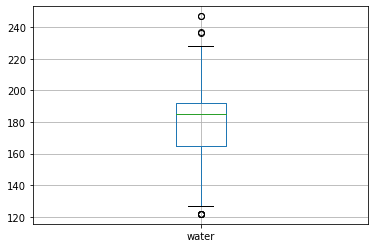

```python
#Scale to Range Feature Engineering Technique to Create a New Feature from Water Column.
#This technique doesn't work well with outliers. So, we will have to find a way to deal with the outliers for the water variable.

#Imputing the whisker values in boxplot for the outliers in water.
conc[['water']].boxplot()

q75, q25 = np.percentile(conc['water'], [75 ,25])
iqr = q75 - q25

#Interquartile range:
print("Interquartile range:")
print(iqr)
print("75th percentile")
print(q75)
print("25th percentile")
print(q25)
print("Upper whisker")
print(q75 + 1.5*iqr)
print("Lower whisker")
print(q25 - 1.5*iqr)
```

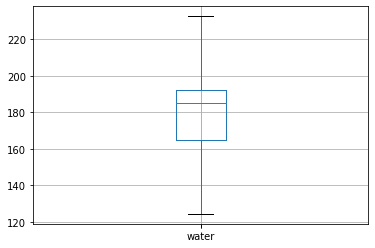

```python
#RUN THIS CELL TWICE TO HANDLE OUTLIERS ON BOTH ENDS OF THE WHISKERS
#Imputing the outliers above the upper whisker with the upper whisker value
conc.water[conc['water']>232.64] = 232.6499
conc[['water']].boxplot()
#Imputing the outliers below the lower whisker with the lower whisker value. Run twice to make sure.
conc.water[conc['water']<124.25000000000002] = 124.25000000000001
conc[['water']].boxplot()
```

```
Interquartile range:
142.95
75th percentile
142.95
25th percentile
0.0
Upper whisker
357.375
Lower whisker
-214.42499999999998
```

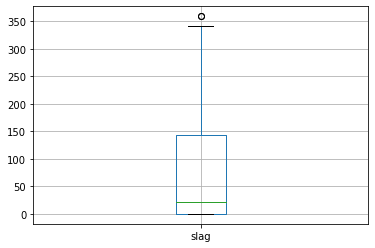

```python
#Imputing the whisker values in boxplot for the outliers in water.
conc[['slag']].boxplot()

q75, q25 = np.percentile(conc['slag'], [75 ,25])
iqr = q75 - q25

#Interquartile range:
print("Interquartile range:")
print(iqr)
print("75th percentile")
print(q75)
print("25th percentile")
print(q25)
print("Upper whisker")
print(q75 + 1.5*iqr)
print("Lower whisker")
print(q25 - 1.5*iqr)
```

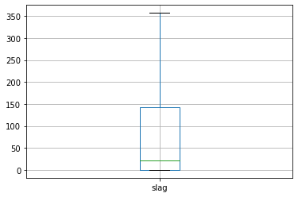

```python
#Imputing the outliers above the upper whisker with the upper whisker value
conc.slag[conc['slag']> 357.375] = 357.375
conc[['slag']].boxplot()
```

```
Interquartile range:
10.2
75th percentile
10.2
25th percentile
0.0
Upper whisker
25.5
Lower whisker
-15.299999999999999
```

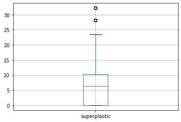

```python
#Imputing the whisker values in boxplot for the outliers in water.
conc[['superplastic']].boxplot()

q75, q25 = np.percentile(conc['superplastic'], [75 ,25])
iqr = q75 - q25

#Interquartile range:
print("Interquartile range:")
print(iqr)
print("75th percentile")
print(q75)
print("25th percentile")
print(q25)
print("Upper whisker")
print(q75 + 1.5*iqr)
print("Lower whisker")
print(q25 - 1.5*iqr)
```

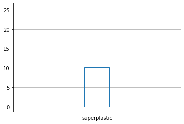

```python
#Imputing the outliers above the upper whisker with the upper whisker value
conc.superplastic[conc['superplastic']> 25.5] = 25.5
conc[['superplastic']].boxplot()
```

```
Interquartile range:
93.05000000000007
75th percentile
824.0
25th percentile
730.9499999999999
Upper whisker
963.575
Lower whisker
591.3749999999998
```

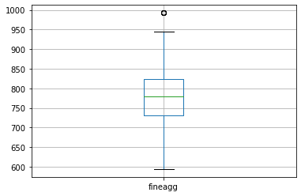

```python
#Imputing the whisker values in boxplot for the outliers in water.
conc[['fineagg']].boxplot()

q75, q25 = np.percentile(conc['fineagg'], [75 ,25])
iqr = q75 - q25

#Interquartile range:
print("Interquartile range:")
print(iqr)
print("75th percentile")
print(q75)
print("25th percentile")
print(q25)
print("Upper whisker")
print(q75 + 1.5*iqr)
print("Lower whisker")
print(q25 - 1.5*iqr)
```

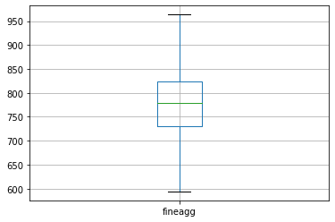

```python
#Imputing the outliers above the upper whisker with the upper whisker value
conc.fineagg[conc['fineagg']> 963.575] = 963.575
conc[['fineagg']].boxplot()
```

```
Interquartile range:
49.0
75th percentile
56.0
25th percentile
7.0
Upper whisker
129.5
Lower whisker
-66.5
```

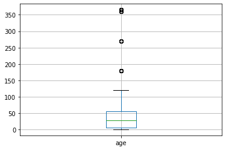

```python
#Imputing the whisker values in boxplot for the outliers in water.
conc[['age']].boxplot()

q75, q25 = np.percentile(conc['age'], [75 ,25])
iqr = q75 - q25

#Interquartile range:
print("Interquartile range:")
print(iqr)
print("75th percentile")
print(q75)
print("25th percentile")
print(q25)
print("Upper whisker")
print(q75 + 1.5*iqr)
print("Lower whisker")
print(q25 - 1.5*iqr)
```

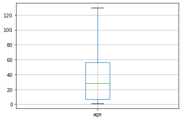

```python
#Imputing the outliers above the upper whisker with the upper whisker value
conc.age[conc['age']> 129.5] = 129.5
conc[['age']].boxplot()
```

```python
#Making the new feature for superplasticizer percent.

conc['superp_percent'] = conc['superplastic']/(conc['cement'] + conc['slag'] + conc['ash'] + conc['water'] + conc['superplastic'] + conc['coarseagg'] + conc['fineagg'])*100
conc.head(10)
```

|  | cement | slag | ash | water | superplastic | coarseagg | fineagg | age | strength | agedays | agg_sand_ratio | water_cem_ratio | superp_percent |
| --- | --- | --- | --- | --- | --- | --- | --- | --- | --- | --- | --- | --- | --- |
| 0 | 141.3 | 212.0 | 0.0 | 203.5 | 0.0 | 971.8 | 748.5 | 28.0 | 29.89 | 4 | 1.298330 | 1.440198 | 0.000000 |
| 1 | 168.9 | 42.2 | 124.3 | 158.3 | 10.8 | 1080.8 | 796.2 | 14.0 | 23.51 | 3 | 1.357448 | 0.937241 | 0.453496 |
| 2 | 250.0 | 0.0 | 95.7 | 187.4 | 5.5 | 956.9 | 861.2 | 28.0 | 29.22 | 4 | 1.111124 | 0.749600 | 0.233377 |
| 3 | 266.0 | 114.0 | 0.0 | 228.0 | 0.0 | 932.0 | 670.0 | 28.0 | 45.85 | 4 | 1.391045 | 0.857143 | 0.000000 |
| 4 | 154.8 | 183.4 | 0.0 | 193.3 | 9.1 | 1047.4 | 696.7 | 28.0 | 18.29 | 4 | 1.503373 | 1.248708 | 0.398302 |
| 5 | 255.0 | 0.0 | 0.0 | 192.0 | 0.0 | 889.8 | 945.0 | 90.0 | 21.86 | 5 | 0.941587 | 0.752941 | 0.000000 |
| 6 | 166.8 | 250.2 | 0.0 | 203.5 | 0.0 | 975.6 | 692.6 | 7.0 | 15.75 | 2 | 1.408605 | 1.220024 | 0.000000 |
| 7 | 251.4 | 0.0 | 118.3 | 188.5 | 6.4 | 1028.4 | 757.7 | 56.0 | 36.64 | 5 | 1.357265 | 0.749801 | 0.272259 |
| 8 | 296.0 | 0.0 | 0.0 | 192.0 | 0.0 | 1085.0 | 765.0 | 28.0 | 21.65 | 4 | 1.418301 | 0.648649 | 0.000000 |
| 9 | 155.0 | 184.0 | 143.0 | 194.0 | 9.0 | 880.0 | 699.0 | 28.0 | 28.99 | 4 | 1.258941 | 1.251613 | 0.397527 |

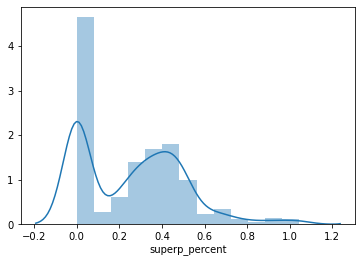

```python
sns.distplot(conc['superp_percent'])
```

## 1. Algorithms that you think will be suitable for this project. Use Kfold Cross-Validation to evaluate model performance. Use appropriate metrics and make a DataFrame to compare models w.r.t their metrics. (at least 3 algorithms, one bagging and one boosting based algorithms have to be there). (15 marks)

It's important to note that certain regression models are very sensitive to multicollinearity, outliers, and non-standardized/non-normalized data columns. These models include: linear regression, Support Vector Regression, and K Nearest Neighbors. Tree models like Decision Tree and Random Forest are robust enough, where these factors don't really influence the measures. Bagging, and boosting models whose base estimators are decision tree are also robust enough.

I created a pipeline for linear regression, support vector regression and K Nearest Neighbors that contain a scaler(Standardscaler)/normalizer(MinMaxScaler) that will standardize/normalize the data.

Accuracy for a regression model is the R^2 value. Just like measuring accuracy in a classification problem, R^2 is not the most ideal metric to understand how well the model fits the data. R Square can determine how well the model fits the dependent variables and explains how much of the variance in the dependent variable can be explained by the independent variable(s) in the model. However, it does not take into consideration the issue of overfitting. Mean Squared Error, on the hand, is better at measuring a model's goodness of fit and reports underfitting and overfitting. Both mean squared error and root mean square share the same purpose, and in this assignment mean squared error will be measured.

Overall, both R^2 and mean squared error and mean absolute error measure a model's statistical robustness.

### LINEAR REGRESSION BASIC MODEL:

```python
#Importing all the necessary packages for our model.
from sklearn.model_selection import train_test_split
from sklearn.linear_model import LinearRegression
from sklearn.model_selection import KFold
from sklearn.model_selection import cross_val_score
from sklearn.pipeline import Pipeline
from sklearn.preprocessing import StandardScaler
import numpy as np
import warnings
warnings.filterwarnings('ignore')

#Separate independent features from target feature.
X = conc.drop(['age','strength'], axis=1)
# the dependent variable
Y = conc[['strength']]

#Making the test set 20% of the entire dataframe
x_remaining, x_test, y_remaining, y_test = train_test_split(X, Y, test_size=0.20, random_state=1)

#Making the validation set 20% of the entire dataframe (25% of the remaining data from the last split)
x_train, x_val, y_train, y_val = train_test_split(x_remaining, y_remaining, test_size=0.25, random_state=1)

#The problem with the linear regression model is that the independent variables have to be standardized so that each variable is on the same scale to limit bias towards features with larger value ranges.
#All the original variables (except for age) all have the same units of measurement and would normally not need to be standardized.
#Because we converted age to an ordinal variable and it is no longer continuous, ordinal variables do not need to be standardized.
#HOWEVER, because I created all these new features that are ratios, and percentages, and are no longer in the same scale as the other continuous variables, using a scaler is important so that results from the linear regression model are not biased towards the features with the higher range values.

#Create pipeline that has standardization scaler.
pipeline = Pipeline([
    ('scaler',StandardScaler()),
    ('clf', LinearRegression())
])

#Fit the model created from pipeline onto the training data.
pipeline.fit(x_train, y_train)



for idx, col_name in enumerate(x_train.columns):
    print("The coefficient for {} is {}".format(col_name, pipeline['clf'].coef_[0][idx]))
```

```
The coefficient for cement is 12.156184410930297
The coefficient for slag is 8.058761346145825
The coefficient for ash is 4.882719756287875
The coefficient for water is -1.8415832196362958
The coefficient for superplastic is 64.3825420610818
The coefficient for coarseagg is 5.764183438974145
The coefficient for fineagg is -5.061753699206828
The coefficient for agedays is 10.393514196189281
The coefficient for agg_sand_ratio is -8.782039997050243
The coefficient for water_cem_ratio is -0.5035254199048541
The coefficient for superp_percent is -63.539514505925474
```

```python
#R^2 value for training data
print("R-squared value for training data")
print(pipeline.score(x_train, y_train)) #Score for linear regression returns the R^2 coefficient (according to sklearn documentation)
print("")


#Cross-validation for R^2 on Validation Set
folds = KFold(n_splits = 50, shuffle = True, random_state = 100)
lrscores = cross_val_score(pipeline, x_train, y_train, scoring='r2', cv=folds)
print("R^2 results for 10 iterations")
print(lrscores)
print("Average of all R^2 iterations and 2 standard deviations")
print("R^2: %.3f (%.3f)" % (rfscores.mean(), rfscores.std()*2))


#Mean Squared Error:
print("Mean Squared Error")
#Mean squared error is to evaluate goodness of fit of the model on the training and validation data.
from sklearn.metrics import mean_squared_error
#from sklearn.model_selection import cross_val_score
print("Calculate mean squared error for training data")
lr_concrete_strength_predict = pipeline.predict(x_train)
print("Mean Squared Error for our Training data")
print(mean_squared_error(y_train, lr_concrete_strength_predict))
print("Mean Squared Error for our Validation data")
print(mean_squared_error(y_val, pipeline.predict(x_val)))
```

```
R-squared value for training data
0.8312567290441221

R^2 results for 10 iterations
[0.49500121 0.88748962 0.81412736 0.64021046 0.83118787 0.89682643
 0.71819282 0.85588302 0.87534982 0.84404998 0.82500785 0.73387903
 0.89480423 0.72256119 0.89039852 0.7468181  0.79179355 0.84320081
 0.8367311  0.86729432 0.82581244 0.81731402 0.75455167 0.61305814
 0.81260572 0.61331612 0.58807904 0.66572947 0.79207257 0.75600902
 0.90613146 0.64534671 0.75560225 0.86538561 0.83663782 0.76525066
 0.82212158 0.860319   0.8304249  0.68294217 0.6613802  0.72482818
 0.90642822 0.92492303 0.77060533 0.90282042 0.72740158 0.78238779
 0.89935634 0.73020525]
Average of all R^2 iterations and 2 standard deviations
R^2: 0.834 (0.192)
Mean Squared Error
Calculate mean squared error for training data
Mean Squared Error for our Training data
44.32846059672197
Mean Squared Error for our Validation data
51.49516499111835
```

Looking at the results, R-squared values are close for the training and validation data. The mean squared error for training data was 44.3, and the mean squared error on the validation set was 51.5 on the validation set using k-fold cross-validation. From this, we can see there is a little bit of overfitting. Looking at the standard deviation from cross-validation, R^2 from the training data falls in the 95% confidence interval (calculated from the 2 standard deviations) from cross-validation.

This suggests that the model is tolerable in its goodness of fit, but there is still some overfitting issues that could be resolved by reducing some of the less important polynomial features in the linear equation.

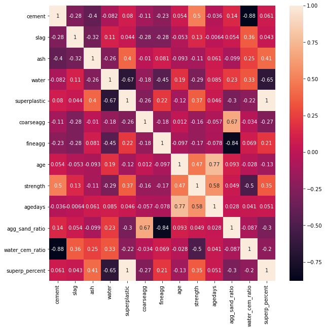

```python
#Heatmap to Measure Correlation (including new features)
fig, ax = plt.subplots(figsize=(10,10))
sns.heatmap(conc.corr(), annot = True);
```

```python
#Model Tuning for linear regression

#Separate independent features from target feature.
X = conc.drop(['age','strength','water_cem_ratio','agg_sand_ratio'], axis=1) #Removing features that are less contributive and reducing collinearity.
# the dependent variable
Y = conc[['strength']]

#Making the test set 20% of the entire dataframe
x_remaining, x_test, y_remaining, y_test = train_test_split(X, Y, test_size=0.20, random_state=1)

#Making the validation set 20% of the entire dataframe (25% of the remaining data from the last split)
x_train, x_val, y_train, y_val = train_test_split(x_remaining, y_remaining, test_size=0.25, random_state=1)

#The problem with the linear regression model is that the independent variables have to be standardized so that each variable is on the same scale to limit bias towards features with larger value ranges.
#All the original variables (except for age) all have the same units of measurement and would normally not need to be standardized.
#Because we converted age to an ordinal variable and it is no longer continuous, ordinal variables do not need to be standardized.
#HOWEVER, because I created all these new features that are ratios, and percentages, and are no longer in the same scale as the other continuous variables, using a scaler is important so that results from the linear regression model are not biased towards the features with the higher range values.

#Create pipeline that has standardization scaler.
pipeline = Pipeline([
    ('scaler',StandardScaler()),
    ('clf', LinearRegression())
])

#Fit the model created from pipeline onto the training data.
pipeline.fit(x_train, y_train)



for idx, col_name in enumerate(x_train.columns):
    print("The coefficient for {} is {}".format(col_name, pipeline['clf'].coef_[0][idx]))
```

```
The coefficient for cement is 12.097569191292479
The coefficient for slag is 7.84415368949313
The coefficient for ash is 5.000957325455943
The coefficient for water is -2.1477894983257686
The coefficient for superplastic is 65.35989803076207
The coefficient for coarseagg is 0.9898676980911577
The coefficient for fineagg is 1.1996543853616928
The coefficient for agedays is 10.35224935899362
The coefficient for superp_percent is -64.69308876173696
```

## LINEAR REGRESSION AFTER HYPERPARAMETER TUNING

```python
#R^2 value for training data
print("R-squared value for training data")
R2_train= pipeline.score(x_train, y_train) #Score for linear regression returns the R^2 coefficient (according to sklearn documentation)
print(R2_train)

#Cross-validation for R^2 on Validation Set
folds = KFold(n_splits = 50, shuffle = True, random_state = 100)
lrscores = cross_val_score(pipeline, x_train, y_train, scoring='r2', cv=folds)
print("R^2 results for 10 iterations")
print(lrscores)
print("Average of all R^2 iterations and 2 standard deviations")
R2_val_cross_val = "R^2: %.3f (%.3f)" % (lrscores.mean(), lrscores.std()*2)
print(R2_val_cross_val)

#Mean Squared Error:
print("Mean Squared Error")
#Mean squared error is to evaluate goodness of fit of the model on the training and validation data.
from sklearn.metrics import mean_squared_error
#from sklearn.model_selection import cross_val_score
print("Calculate mean squared error for training data")
lr_concrete_strength_predict = pipeline.predict(x_train)
print("Mean Squared Error for our Training data")
MSE_train = mean_squared_error(y_train, lr_concrete_strength_predict)
print(MSE_train)
print("Mean Squared Error for our Validation data")
MSE_val = mean_squared_error(y_val, pipeline.predict(x_val))
print(MSE_val)
print("")
```

```
R-squared value for training data
0.825892037097684
R^2 results for 10 iterations
[0.43750126 0.8705789  0.80487896 0.59988899 0.81320912 0.88575577
 0.75554468 0.85071066 0.8617748  0.86095272 0.81619182 0.70499163
 0.88408804 0.70537341 0.88633678 0.75710736 0.81360468 0.84833745
 0.81904081 0.86696338 0.82000528 0.80964409 0.79088474 0.65472647
 0.83309979 0.6488868  0.5685653  0.70891859 0.76478238 0.71156175
 0.90183114 0.66380675 0.77041145 0.85083585 0.82686806 0.7623406
 0.80555048 0.84520852 0.82699928 0.64176434 0.6730116  0.68555971
 0.8997524  0.91223488 0.83809611 0.87629162 0.71189405 0.80514788
 0.89291275 0.7387858 ]
Average of all R^2 iterations and 2 standard deviations
R^2: 0.782 (0.196)
Mean Squared Error
Calculate mean squared error for training data
Mean Squared Error for our Training data
45.7377525596792
Mean Squared Error for our Validation data
51.40988820314021
```

We reduced the overfitting by a little, but it seems that there will be a little overfitting nonetheless. The mean squared error is still high for training and from cross-validation, suggesting that linear regression may not be the best fit model for this data, despite the ability to reduce the overfitting by a little. We can now test the model on the test data.

```python
print("R-squared for test data")
R2_test = pipeline.score(x_test,y_test)
print(R2_test)

print("MSE of model on test data")
MSE_test = mean_squared_error(y_test, pipeline.predict(x_test))
print(MSE_test)
```

```
R-squared for test data
0.8292322168089732
MSE of model on test data
50.285855723347446
```

Clearly, the R^2 from the test data is within the range of the 95% confidence interval (0.586-0.978) that we achieved in the cross-validation. So, even though the model is a little overfit, linear regression is still a tolerable model (not the best fit model) to carry into production for predicting the strength of concrete with the more important features.

```python
Linear_Regression ={'Metrics':['R2_train', 'R2_val_cross_val (+2 sd)', 'R2_test', 'MSE_train', 'MSE_val', 'MSE_test'], 'Linear_Regression':[R2_train, R2_val_cross_val, R2_test, MSE_train, MSE_val, MSE_test]}
Linear_Regression_= pd.DataFrame(Linear_Regression)
Linear_Regression_
```

|  | Metrics | Linear_Regression |
| --- | --- | --- |
| 0 | R2_train | 0.825892 |
| 1 | R2_val_cross_val (+2 sd) | R^2: 0.782 (0.196) |
| 2 | R2_test | 0.829232 |
| 3 | MSE_train | 45.7378 |
| 4 | MSE_val | 51.4099 |
| 5 | MSE_test | 50.2859 |

```python
#Reset the x dataset back to the form before the linear regression model tuning because tree models like decision tree and random forest are robust.

#Separate independent features from target feature.
X = conc.drop(['age','strength'], axis=1)
# the dependent variable
Y = conc[['strength']]

#Making the test set 20% of the entire dataframe
x_remaining, x_test, y_remaining, y_test = train_test_split(X, Y, test_size=0.20, random_state=1)

#Making the validation set 20% of the entire dataframe (25% of the remaining data from the last split)
x_train, x_val, y_train, y_val = train_test_split(x_remaining, y_remaining, test_size=0.25, random_state=1)
```

### DECISION TREE BASIC MODEL

```python
#Decision Tree
#Decision tree doesn't require any standardization because the model is robust to the magnitude of variables.
from sklearn.tree import DecisionTreeRegressor
from sklearn import tree
dTree = DecisionTreeRegressor(random_state=1, criterion='mse', splitter='best', max_depth=10, min_samples_split=2, min_samples_leaf=1, min_weight_fraction_leaf=0.0, max_features=None, max_leaf_nodes=None, min_impurity_decrease=0.0, min_impurity_split=None, presort='deprecated', ccp_alpha=0.0)
dTree.fit(x_train, y_train)
```

```
DecisionTreeRegressor(max_depth=10, random_state=1)
```

```python
print("Decision Tree R^2 value for training data")
dt_R2_train= dTree.score(x_train,y_train)#"Score" is the coefficient of determination R^2 of the prediction for DecisionTreeRegression, according to sklearn
print(dt_R2_train)


#Cross-validation for R^2 on Validation Set
folds = KFold(n_splits = 50, shuffle = True, random_state = 100)
dtscores = cross_val_score(dTree, x_train, y_train, scoring='r2', cv=folds)
print("R^2 results for 10 iterations")
print(dtscores)
print("Average of all R^2 iterations and 2 standard deviation")
dt_R2_val_cross_val= "R^2: %.3f (%.3f)" % (dtscores.mean(), dtscores.std()*2)
print(dt_R2_val_cross_val)


#Mean squared error is to evaluate goodness of fit of the model on the training and validation data.
from sklearn.metrics import mean_squared_error
print("Calculate mean squared error for training data")
dt_concrete_strength_predict = dTree.predict(x_train)
print("Mean Squared Error for our Training data")
dt_MSE_train= mean_squared_error(y_train, dt_concrete_strength_predict)
print(dt_MSE_train)
print("Mean Squared Error for Validation Data")
dt_MSE_val= mean_squared_error(y_val, dTree.predict(x_val))
print(dt_MSE_val)
```

```
Decision Tree R^2 value for training data
0.9845081381122976
R^2 results for 10 iterations
[0.66732121 0.86491564 0.9362959  0.89443349 0.42735141 0.94152559
 0.74577406 0.83734122 0.86021603 0.73433346 0.76683349 0.44488648
 0.8224007  0.79638105 0.77523077 0.80242703 0.77933661 0.91420223
 0.87935185 0.82708626 0.96427124 0.40548425 0.27621146 0.67530468
 0.85192959 0.17241255 0.80005393 0.7690281  0.96303399 0.79788153
 0.91718918 0.76031192 0.88795739 0.92748808 0.861259   0.839145
 0.90822    0.58365673 0.77684555 0.88152364 0.75620961 0.65166122
 0.82959368 0.87207969 0.93173575 0.72025565 0.79484985 0.62426214
 0.9615928  0.7286571 ]
Average of all R^2 iterations and 2 standard deviation
R^2: 0.772 (0.341)
Calculate mean squared error for training data
Mean Squared Error for our Training data
4.069675699473874
Mean Squared Error for Validation Data
48.15283769446304
```

```python
dTree = DecisionTreeRegressor(max_depth = 6, random_state=1, min_impurity_decrease=1, min_samples_leaf=2)
dTree.fit(x_train, y_train)

#Mean squared error is to evaluate goodness of fit of the model on the training and validation data.
from sklearn.metrics import mean_squared_error
from sklearn.model_selection import cross_val_score

print("Decision Tree R^2 value for training data")
dt_R2_train= dTree.score(x_train,y_train)#"Score" is the coefficient of determination R^2 of the prediction for DecisionTreeRegression, according to sklearn
print(dt_R2_train)


#Cross-validation for R^2 on Validation Set
folds = KFold(n_splits = 50, shuffle = True, random_state = 100)
dtscores = cross_val_score(dTree, x_train, y_train, scoring='r2', cv=folds)
print("R^2 results for 10 iterations")
print(dtscores)
print("Average of all R^2 iterations and 2 standard deviation")
dt_R2_val_cross_val= "R^2: %.3f (%.3f)" % (dtscores.mean(), dtscores.std()*2)
print(dt_R2_val_cross_val)


#Mean squared error is to evaluate goodness of fit of the model on the training and validation data.
from sklearn.metrics import mean_squared_error
print("Calculate mean squared error for training data")
dt_concrete_strength_predict = dTree.predict(x_train)
print("Mean Squared Error for our Training data")
dt_MSE_train= mean_squared_error(y_train, dt_concrete_strength_predict)
print(dt_MSE_train)
print("Mean Squared Error for Validation Data")
dt_MSE_val= mean_squared_error(y_val, dTree.predict(x_val))
print(dt_MSE_val)





#scores2 = cross_val_score(dTree, x_val, y_val, scoring='r2', cv=folds)
#print(scores2)

#print("R^2: %.3f (%.3f)" % (scores2.mean(), scores2.std()))

#print(dTree.score(x_test, y_test))
```

```
Decision Tree R^2 value for training data
0.8272750486723355
R^2 results for 10 iterations
[0.28902517 0.87090534 0.8193936  0.75043535 0.45731933 0.91210529
 0.58079906 0.7947995  0.72103025 0.72959973 0.69360609 0.57248136
 0.80290432 0.47663619 0.80702032 0.55607129 0.60290424 0.84912458
 0.67082754 0.87099285 0.8671913  0.74188531 0.17902058 0.83276509
 0.7349286  0.55404574 0.61624689 0.6891639  0.91497365 0.39633155
 0.7792286  0.39033547 0.85395616 0.8355274  0.74241703 0.71251322
 0.78988822 0.75463169 0.83509389 0.81199121 0.69810994 0.83490425
 0.75472382 0.8112971  0.6204671  0.85986869 0.53500205 0.74970594
 0.92108858 0.15400186]
Average of all R^2 iterations and 2 standard deviation
R^2: 0.696 (0.361)
Calculate mean squared error for training data
Mean Squared Error for our Training data
45.374438670215845
Mean Squared Error for Validation Data
55.5331690417149
```

The R^2 isn't the best method to evaluate overfitting. Looking at the R^2 values for this newly revised model, the R^2 values for the training and cross validation are closer. The mean squared errors for the validation set and the training set are not that far apart either, so there is just a little bit of overfitting. No matter how much I prune and tune the hyperparameters, it will still be a little overfit. However, we tuned the model so that the MSE for the training is not so close to 0, and is able to be generalizable to the validation set, and possibly the test set. The model is decent to carry out to production, if the R^2 values displayed here are considered somewhat acceptable.

```python
print("R-squared for test data")
dt_R2_test = dTree.score(x_test,y_test)
print(dt_R2_test)

print("MSE of model on test data")
dt_MSE_test = mean_squared_error(y_test, dTree.predict(x_test))
print(dt_MSE_test)
```

```
R-squared for test data
0.796746880002215
MSE of model on test data
59.851787477357746
```

After testing on the testing data, the R^2 is within the acceptable 95% Confidence interval but the model is still somewhat overfit because the MSE is slightly more than the training and the validation test set.

```python
Decision_Tree ={'Metrics':['R2_train', 'R2_val_cross_val (+2 sd)', 'R2_test', 'MSE_train', 'MSE_val', 'MSE_test'], 'Decision_Tree':[dt_R2_train, dt_R2_val_cross_val, dt_R2_test, dt_MSE_train, dt_MSE_val, dt_MSE_test]}
Decision_Tree_= pd.DataFrame(Decision_Tree)
Decision_Tree_
```

|  | Metrics | Decision_Tree |
| --- | --- | --- |
| 0 | R2_train | 0.827275 |
| 1 | R2_val_cross_val (+2 sd) | R^2: 0.696 (0.361) |
| 2 | R2_test | 0.796747 |
| 3 | MSE_train | 45.3744 |
| 4 | MSE_val | 55.5332 |
| 5 | MSE_test | 59.8518 |

## RANDOM FOREST

```python
#Random Forest
from sklearn.ensemble import RandomForestRegressor

rfr = RandomForestRegressor(random_state = 100, n_estimators=100, max_depth=None, bootstrap=True)
rfr.fit(x_train, y_train)
#R-Square for Training Data
print("R-squared for training data")
rf_R2_train = rfr.score(x_train,y_train)
print(rf_R2_train)

#Cross-validation for R^2.
folds = KFold(n_splits = 50, shuffle = True, random_state = 100)
rfscores = cross_val_score(rfr, x_train, y_train, scoring='r2', cv=folds)
print("R^2 results for 10 iterations")
print(rfscores)
print("Average of all R^2 iterations and 2 standard deviations")
rf_R2_val_cross_val= "R^2: %.3f (%.3f)" % (rfscores.mean(), rfscores.std()*2)
print(rf_R2_val_cross_val)
print("")

#Mean Squared Error:
print("Mean Squared Error")
#Mean squared error is to evaluate goodness of fit of the model on the training and validation data.
from sklearn.metrics import mean_squared_error
#from sklearn.model_selection import cross_val_score
print("Calculate mean squared error for training data")
rf_concrete_strength_predict = rfr.predict(x_train)
print("Mean Squared Error for our Training data")
rf_MSE_train = mean_squared_error(y_train, rf_concrete_strength_predict)
print(rf_MSE_train)

print("Mean Squared Error for our Validation data")
rf_MSE_val= mean_squared_error(y_val, rfr.predict(x_val))
print(rf_MSE_val)
```

```
R-squared for training data
0.9836715318698851
R^2 results for 10 iterations
[0.6896989  0.91720805 0.95472043 0.9301504  0.89653824 0.94704627
 0.91041333 0.93374777 0.86649732 0.91760436 0.78582571 0.77104953
 0.91648106 0.86930442 0.85282187 0.8470381  0.90680358 0.94568716
 0.9274303  0.89318936 0.97052765 0.8447633  0.56352674 0.8082026
 0.87697767 0.7043279  0.92398224 0.86431879 0.97036973 0.92352806
 0.9117169  0.87409063 0.9502558  0.95127327 0.95075582 0.8564797
 0.96304259 0.87164297 0.86050149 0.95762989 0.82625561 0.86748879
 0.94080117 0.95298587 0.88022116 0.93827083 0.82516207 0.76867072
 0.9639309  0.74735162]
Average of all R^2 iterations and 2 standard deviations
R^2: 0.880 (0.163)

Mean Squared Error
Calculate mean squared error for training data
Mean Squared Error for our Training data
4.289450192653249
Mean Squared Error for our Validation data
28.02296003682836
```

Based on these validation results, the R^2 value went down compared to the R^2 value for the training set. This shows that the model is not able to capture as much of the variance around the mean in the validation set.

The overfitting issue is corroborated by the values of the mean squared error, which is a better measure to examine goodness-of-fit for the model. The mean squared error was 4.3 on the training data but is 28 for the validation data. This is a stark difference, explaining how much the model is overfit. The fact how the training MSE is so close to 0 means that the data is so well-trained to the training data.

I will tune the hyperparameters to make the model more generalizable so that it may perform decently on the test data. To prevent overfitting in a random forest model, it is advised to increase the n_estimators (trees), and decrease the max_depth.

```python
rfr = RandomForestRegressor(random_state = 100, n_estimators=120, max_depth=6)
rfr.fit(x_train, y_train)


#R-Square for Training Data
print("R-squared for training data")
rf_R2_train = rfr.score(x_train,y_train)
print(rf_R2_train)

#Cross-validation for R^2.
folds = KFold(n_splits = 50, shuffle = True, random_state = 100)
rfscores = cross_val_score(rfr, x_train, y_train, scoring='r2', cv=folds)
print("R^2 results for 10 iterations")
print(rfscores)
print("Average of all R^2 iterations and 2 standard deviations")
rf_R2_val_cross_val= "R^2: %.3f (%.3f)" % (rfscores.mean(), rfscores.std()*2)
print(rf_R2_val_cross_val)
print("")

#Mean Squared Error:
print("Mean Squared Error")
#Mean squared error is to evaluate goodness of fit of the model on the training and validation data.
from sklearn.metrics import mean_squared_error
#from sklearn.model_selection import cross_val_score
print("Calculate mean squared error for training data")
rf_concrete_strength_predict = rfr.predict(x_train)
print("Mean Squared Error for our Training data")
rf_MSE_train = mean_squared_error(y_train, rf_concrete_strength_predict)
print(rf_MSE_train)

print("Mean Squared Error for our Validation data")
rf_MSE_val= mean_squared_error(y_val, rfr.predict(x_val))
print(rf_MSE_val)
```

```
R-squared for training data
0.9311049520465651
R^2 results for 10 iterations
[0.54525773 0.90095664 0.90610546 0.87298828 0.85274452 0.93929626
 0.85210048 0.90711975 0.85123075 0.8059539  0.78598554 0.77200947
 0.89672233 0.83677191 0.81899107 0.75728639 0.82121913 0.92269417
 0.8706598  0.88926478 0.90234723 0.81409264 0.48962053 0.80484296
 0.8435486  0.5758484  0.76487369 0.83389207 0.94615976 0.8317107
 0.898843   0.8092331  0.92227237 0.92570881 0.9147003  0.82607382
 0.89325272 0.81325203 0.839608   0.92057889 0.78954688 0.87402233
 0.90824758 0.89703667 0.80891014 0.93647746 0.75366215 0.7413066
 0.93120596 0.68233396]
Average of all R^2 iterations and 2 standard deviations
R^2: 0.834 (0.192)

Mean Squared Error
Calculate mean squared error for training data
Mean Squared Error for our Training data
18.09856713819219
Mean Squared Error for our Validation data
36.10356744096461
```

```python
#Testing on the test data

print("R-squared for test data")
rf_R2_test = rfr.score(x_test,y_test)
print(rf_R2_test)

print("MSE of model on test data")
rf_MSE_test = mean_squared_error(y_test, rfr.predict(x_test))
print(rf_MSE_test)
```

```
R-squared for test data
0.8684480655657794
MSE of model on test data
38.737995372853696
```

The MSE for the testing data is a lot closer to the validation set MSE. The model is overfit. I tuned the parameters that are most influential for Random Forest to the best of my ability but the model still remains somewhat overfit.

```python
Random_Forest ={'Metrics':['R2_train', 'R2_val_cross_val (+2 sd)', 'R2_test', 'MSE_train', 'MSE_val', 'MSE_test'], 'Random_Forest':[rf_R2_train, rf_R2_val_cross_val, rf_R2_test, rf_MSE_train, rf_MSE_val, rf_MSE_test]}
Random_Forest_= pd.DataFrame(Random_Forest)
Random_Forest_
```

|  | Metrics | Random_Forest |
| --- | --- | --- |
| 0 | R2_train | 0.931105 |
| 1 | R2_val_cross_val (+2 sd) | R^2: 0.834 (0.192) |
| 2 | R2_test | 0.868448 |
| 3 | MSE_train | 18.0986 |
| 4 | MSE_val | 36.1036 |
| 5 | MSE_test | 38.738 |

### SVR

Support vector regression is also a possible regression choice to determine the strength of concrete. For this model, like linear regression, the dataframe has to be standardized so that all features are of the same scale and similar ranges. Additionally, we must re-remove features of multicollinearity like we did in linear regression.

```python
#Remove the features of multicollinearity (like what we did for the regression model)

#Separate independent features from target feature.
X = conc.drop(['age','strength','water_cem_ratio','agg_sand_ratio'], axis=1) #Removing features that are less contributive and reducing collinearity.
# the dependent variable
Y = conc[['strength']]

#Making the test set 20% of the entire dataframe
x_remaining, x_test, y_remaining, y_test = train_test_split(X, Y, test_size=0.20, random_state=1)

#Making the validation set 20% of the entire dataframe (25% of the remaining data from the last split)
x_train, x_val, y_train, y_val = train_test_split(x_remaining, y_remaining, test_size=0.25, random_state=1)
```

```python
###### SVM
from sklearn.svm import SVR
from sklearn.preprocessing import MinMaxScaler
from sklearn import decomposition, datasets

pipeline_svr = Pipeline([
    ('scaler',MinMaxScaler()),
    ('sv', SVR())
])

print("SVR R^2 training data")
pipeline_svr.fit(x_train,y_train)
SVR(C = 1, degree = 3, gamma=0.22, kernel = 'rbf', max_iter = -1, verbose=False) #Default settings
svr_R2_train = pipeline_svr.score(x_train,y_train)
print(svr_R2_train)
#R2 for SVR training set.
print("SVR R^2 cross validation")
print(svr_R2_train)




folds = KFold(n_splits = 10, shuffle = True, random_state = 100)
svrscores = cross_val_score(pipeline_svr, x_train, y_train, scoring='r2', cv=folds)
print(svrscores)
#Cross-validation R2 mean, and 2 standard deviations
svr_R2_val_cross_val= "R^2: %.3f (%.3f)" % (svrscores.mean(), svrscores.std()*2)
print(svr_R2_val_cross_val)

#Mean Squared Errors (MSE) for Training Set
print("Calculate mean squared error for training data")
svr_concrete_strength_predict = pipeline_svr.predict(x_train)
print("Mean Squared Error for our Training data")
svr_MSE_train = mean_squared_error(y_train, svr_concrete_strength_predict)
print(svr_MSE_train)
#Mean Squared Errors for Validation Set
print("Mean Squared Error for our Validation data")
svr_MSE_val = mean_squared_error(y_val, pipeline_svr.predict(x_val))
print(svr_MSE_val)
```

```
SVR R^2 training data
0.740118047269592
SVR R^2 cross validation
0.740118047269592
[0.70644071 0.70243761 0.61698167 0.68293162 0.71904871 0.68442849
 0.79439835 0.66701733 0.77276578 0.70946812]
R^2: 0.706 (0.096)
Calculate mean squared error for training data
Mean Squared Error for our Training data
68.2703780491566
Mean Squared Error for our Validation data
91.28737767960746
```

The R^2 value is not as high as the other models. The mean square error is really far from 0. There is overfitting, and after trying to tune the hyperparameters, the training and validation values don't seem to change. Perhaps, this is a good model to use for GridSearch CV.

```python
#Testing on the test data

print("R-squared for test data")
svr_R2_test = pipeline_svr.score(x_test,y_test)
print(svr_R2_test)

print("MSE of model on test data")
svr_MSE_test = mean_squared_error(y_test, pipeline_svr.predict(x_test))
print(svr_MSE_test)
```

```
R-squared for test data
0.7584679599456011
MSE of model on test data
71.1237511653749
```

```python
SVR ={'Metrics':['R2_train', 'R2_val_cross_val (+2 sd)', 'R2_test', 'MSE_train', 'MSE_val', 'MSE_test'], 'SVR':[svr_R2_train, svr_R2_val_cross_val, svr_R2_test, svr_MSE_train, svr_MSE_val, svr_MSE_test]}
SVR_= pd.DataFrame(SVR)
SVR_
```

|  | Metrics | SVR |
| --- | --- | --- |
| 0 | R2_train | 0.740118 |
| 1 | R2_val_cross_val (+2 sd) | R^2: 0.706 (0.096) |
| 2 | R2_test | 0.758468 |
| 3 | MSE_train | 68.2704 |
| 4 | MSE_val | 91.2874 |
| 5 | MSE_test | 71.1238 |

### K Nearest Neighbors

```python
#K-Nearest Neighbors
from sklearn.neighbors import KNeighborsRegressor
pipeline_knn = Pipeline([
    ('scaler',MinMaxScaler()),
    ('knr', KNeighborsRegressor())
])

pipeline_knn.fit(x_train,y_train)
KNeighborsRegressor(n_neighbors=100, p=2)
#KNN R2 Training
print("KNN R2 for Training data")
knn_R2_train = pipeline_knn.score(x_train,y_train)
print(knn_R2_train)

#K-Fold cross-validation for R2
folds = KFold(n_splits = 10, shuffle = True, random_state = 100)
knnscores = cross_val_score(pipeline_knn, x_train, y_train, scoring='r2', cv=folds)
print(knnscores)
print("KNN, R2, cross-validation")
knn_R2_val_cross_val = "R^2: %.3f (%.3f)" % (knnscores.mean(), knnscores.std())
print(knn_R2_val_cross_val)

#Mean Squared Errors (MSE) for Training Set
print("Calculate mean squared error for training data")
knn_concrete_strength_predict = pipeline_knn.predict(x_train)
print("Mean Squared Error for our Training data")
knn_MSE_train = mean_squared_error(y_train, knn_concrete_strength_predict)
print(knn_MSE_train)
print("Mean Squared Error for our Validation data")
knn_MSE_val = mean_squared_error(y_val, pipeline_knn.predict(x_val))
print(knn_MSE_val)
```

```
KNN R2 for Training data
0.8846792072976158
[0.80728762 0.81175462 0.69937797 0.71991783 0.8345524  0.70126887
 0.84332412 0.81760486 0.85250545 0.85546211]
KNN, R2, cross-validation
R^2: 0.794 (0.059)
Calculate mean squared error for training data
Mean Squared Error for our Training data
30.294501145631067
Mean Squared Error for our Validation data
59.42099811650485
```

K Nearest Neighbors model is pretty good for this data, despite high overfitting. The R2 value is good, and can perhaps be improved if we ran GridSearch CV on this. Like SVR, tuning the hyperameters manually did not have much of a difference on controlling the overfitting of the model to the data.

```python
#Testing on the test data

print("R-squared for test data")
knn_R2_test = pipeline_knn.score(x_test,y_test)
print(knn_R2_test)

print("MSE of model on test data")
knn_MSE_test = mean_squared_error(y_test, pipeline_knn.predict(x_test))
print(knn_MSE_test)
```

```
R-squared for test data
0.8296745642449213
MSE of model on test data
50.155598019417475
```

```python
KNN ={'Metrics':['R2_train', 'R2_val_cross_val (+2 sd)', 'R2_test', 'MSE_train', 'MSE_val', 'MSE_test'], 'K Nearest_Neighbors':[knn_R2_train, knn_R2_val_cross_val, knn_R2_test, knn_MSE_train, knn_MSE_val, knn_MSE_test]}
KNN_= pd.DataFrame(KNN)
KNN_
```

|  | Metrics | K Nearest_Neighbors |
| --- | --- | --- |
| 0 | R2_train | 0.884679 |
| 1 | R2_val_cross_val (+2 sd) | R^2: 0.794 (0.059) |
| 2 | R2_test | 0.829675 |
| 3 | MSE_train | 30.2945 |
| 4 | MSE_val | 59.421 |
| 5 | MSE_test | 50.1556 |

```python
#Reset the x dataset back to the form before the linear regression model tuning because tree models like decision tree and random forest are robust.

#Separate independent features from target feature.
X = conc.drop(['age','strength'], axis=1)
# the dependent variable
Y = conc[['strength']]

#Making the test set 20% of the entire dataframe
x_remaining, x_test, y_remaining, y_test = train_test_split(X, Y, test_size=0.20, random_state=1)

#Making the validation set 20% of the entire dataframe (25% of the remaining data from the last split)
x_train, x_val, y_train, y_val = train_test_split(x_remaining, y_remaining, test_size=0.25, random_state=1)
```

```python
#Bagging Model:

from sklearn.ensemble import BaggingRegressor
from sklearn.datasets import make_regression
bagr = BaggingRegressor(n_estimators=100, random_state=1)  # Base estimator is DecisionTree


bagr = bagr.fit(x_train, y_train)
print("R2 Training Set")
bag_R2_train = bagr.score(x_train, y_train)
print(bag_R2_train)

#Cross-validation of R2 value on validation set
folds = KFold(n_splits = 50, shuffle = True, random_state = 100)
bagscores = cross_val_score(bagr, x_train, y_train, scoring='r2', cv=folds)
print(bagscores)
print("Cross-Validation R2")
bag_R2_val_cross_val = "R^2: %.3f (%.3f)" % (bagscores.mean(), bagscores.std())
print(bag_R2_val_cross_val)
print("")

#Mean Squared Errors (MSE) for Training Set
print("Calculate mean squared error for training data")
bag_concrete_strength_predict = bagr.predict(x_train)
print("Mean Squared Error for our Training data")
bag_MSE_train= mean_squared_error(y_train, bag_concrete_strength_predict)
print(bag_MSE_train)
print("Mean Squared Error for our Validation data")
bag_MSE_val= mean_squared_error(y_val, bagr.predict(x_val))
print(bag_MSE_val)
```

```
R2 Training Set
0.9837707214415985
[0.68658224 0.9154693  0.95748554 0.93224564 0.88807742 0.95206685
 0.90634745 0.93637376 0.85994538 0.89854458 0.81738289 0.74933175
 0.9027082  0.89727068 0.83905986 0.85933628 0.88940489 0.95136151
 0.94068931 0.89933231 0.97267986 0.86637439 0.51077139 0.80221006
 0.8690555  0.75268774 0.91430265 0.87060934 0.96363483 0.91814611
 0.91351308 0.84473803 0.96460188 0.96529085 0.93706062 0.85386034
 0.96003057 0.84814449 0.86025824 0.95948652 0.82604849 0.87303513
 0.92876584 0.96039847 0.88409817 0.92929369 0.84356786 0.79395554
 0.96914715 0.76589699]
Cross-Validation R2
R^2: 0.880 (0.083)

Calculate mean squared error for training data
Mean Squared Error for our Training data
4.263393325339971
Mean Squared Error for our Validation data
28.548922897223704
```

```python
print("Bagging Model R^2 Value for Test Data")
bag_R2_test = bagr.score(x_test, y_test)
print(bag_R2_test)
print("Bagging Model MSE Value for Test Data")
bag_MSE_test = mean_squared_error(y_test, bagr.predict(x_test))
print(bag_MSE_test)
```

```
Bagging Model R^2 Value for Test Data
0.9063471504025455
Bagging Model MSE Value for Test Data
27.577881465322047
```

After manually attempting to tune the hyperparameters, the model and results do not change much. The n_estimators, whether 100 or 1000 did not show any difference.

```python
Bagging ={'Metrics':['R2_train', 'R2_val_cross_val (+2 sd)', 'R2_test', 'MSE_train', 'MSE_val', 'MSE_test'], 'Bagging':[bag_R2_train, bag_R2_val_cross_val, bag_R2_test, bag_MSE_train, bag_MSE_val, bag_MSE_test]}
Bagging_= pd.DataFrame(Bagging)
Bagging_
```

|  | Metrics | Bagging |
| --- | --- | --- |
| 0 | R2_train | 0.983771 |
| 1 | R2_val_cross_val (+2 sd) | R^2: 0.880 (0.083) |
| 2 | R2_test | 0.906347 |
| 3 | MSE_train | 4.26339 |
| 4 | MSE_val | 28.5489 |
| 5 | MSE_test | 27.5779 |

```python
#Gradient Boost Model


from sklearn.ensemble import GradientBoostingRegressor
from sklearn.datasets import make_regression
gbr = GradientBoostingRegressor(n_estimators=100, random_state=1)  # Base estimator is DecisionTreeRegressor, max_depth=3
gbr = gbr.fit(x_train, y_train)
print("R2 training")
gb_R2_train = gbr.score(x_train, y_train)
print(gb_R2_train)
#Cross-validation of R2 value on validation set
folds = KFold(n_splits = 50, shuffle = True, random_state = 100)
gradbscores = cross_val_score(gbr, x_train, y_train, scoring='r2', cv=folds)
print(gradbscores)
gb_R2_val_cross_val= "R^2: %.3f (%.3f)" % (gradbscores.mean(), gradbscores.std())
print(gb_R2_val)
print("")

#Mean Squared Errors (MSE) for Training Set
print("Calculate mean squared error for training data")
gradb_concrete_strength_predict = gbr.predict(x_train)
print("Mean Squared Error for our Training data")
gb_MSE_train = mean_squared_error(y_train, gradb_concrete_strength_predict)
print(gb_MSE_train)
#Mean Squared Error for Validation Set
print("Mean Squared Error for our Validation data")
gb_MSE_val= mean_squared_error(y_val, gbr.predict(x_val))
print(gb_MSE_val)
```

[output not shown]

```python
print("Gradient Boost R^2 Value for Test Data")
gb_R2_test = gbr.score(x_test, y_test)
print(gb_R2_test)
print("Gradient Boost MSE Value for Test Data")
gb_MSE_test = mean_squared_error(y_test, gbr.predict(x_test))
print(gb_MSE_test)
```

```
Gradient Boost R^2 Value for Test Data
0.9080880111696099
Gradient Boost MSE Value for Test Data
27.06525155509415
```

```python
Gradient_Boost ={'Metrics':['R2_train', 'R2_val_cross_val (+2 sd)', 'R2_test', 'MSE_train', 'MSE_val', 'MSE_test'], 'Gradient_Boost':[gb_R2_train, gb_R2_val_cross_val, gb_R2_test, gb_MSE_train, gb_MSE_val, gb_MSE_test]}
Gradient_Boost_= pd.DataFrame(Gradient_Boost)
Gradient_Boost_
```

|  | Metrics | Gradient_Boost |
| --- | --- | --- |
| 0 | R2_train | 0.955056 |
| 1 | R2_val_cross_val (+2 sd) | R^2: 0.874 (0.079) |
| 2 | R2_test | 0.908088 |
| 3 | MSE_train | 11.8066 |
| 4 | MSE_val | 28.5608 |
| 5 | MSE_test | 27.0653 |

```python
Metrics_Dataframe = pd.merge(Linear_Regression_,Decision_Tree_,how='outer',on='Metrics')
Metrics_Dataframe = pd.merge(Metrics_Dataframe,Random_Forest_,how='outer',on='Metrics')
Metrics_Dataframe = pd.merge(Metrics_Dataframe,SVR_,how='outer',on='Metrics')
Metrics_Dataframe = pd.merge(Metrics_Dataframe,KNN_,how='outer',on='Metrics')
Metrics_Dataframe = pd.merge(Metrics_Dataframe,Bagging_,how='outer',on='Metrics')
Metrics_Dataframe = pd.merge(Metrics_Dataframe,Gradient_Boost_,how='outer',on='Metrics')
Metrics_Dataframe
```

|  | Metrics | Linear_Regression | Decision_Tree | Random_Forest | SVR | K Nearest_Neighbors | Bagging | Gradient_Boost |
| --- | --- | --- | --- | --- | --- | --- | --- | --- |
| 0 | R2_train | 0.825892 | 0.827275 | 0.931105 | 0.740118 | 0.884679 | 0.983771 | 0.955056 |
| 1 | R2_val_cross_val (+2 sd) | R^2: 0.782 (0.196) | R^2: 0.696 (0.361) | R^2: 0.834 (0.192) | R^2: 0.706 (0.096) | R^2: 0.794 (0.059) | R^2: 0.880 (0.083) | R^2: 0.874 (0.079) |
| 2 | R2_test | 0.829232 | 0.796747 | 0.868448 | 0.758468 | 0.829675 | 0.906347 | 0.908088 |
| 3 | MSE_train | 45.7378 | 45.3744 | 18.0986 | 68.2704 | 30.2945 | 4.26339 | 11.8066 |
| 4 | MSE_val | 51.4099 | 55.5332 | 36.1036 | 91.2874 | 59.421 | 28.5489 | 28.5608 |
| 5 | MSE_test | 50.2859 | 59.8518 | 38.738 | 71.1238 | 50.1556 | 27.5779 | 27.0653 |

### Techniques employed to squeeze that extra performance out of the model without making it overfit. Use Grid Search or Random Search on any of the two models used above. Make a DataFrame to compare models after hyperparameter tuning and their metrics as above. (15 marks)

### GRID SEARCH CV to the Gradient Boost Model

```python
#Performing GridSearch CV on the Gradient Boost Model Validation Set

from sklearn.model_selection import GridSearchCV
search_grid={'n_estimators':[100,200,300,500],'max_depth':[1,2,4,6,8],'random_state':[1]}
gsgradientb=GridSearchCV(estimator=gbr,param_grid=search_grid,scoring='r2',n_jobs=1,cv=10)

gsgradientb.fit(x_val, y_val)

#Compare the results to the training using this Gridsearch CV technique.
grids_gradientb_R2_train = gsgradientb.score(x_train, y_train)
print(grids_gradientb_R2_train)
```

```
0.8543969085881351
```

```python
#Finding the best parameters
gsgradientb.best_params_
```

```
{'max_depth': 2, 'n_estimators': 200, 'random_state': 1}
```

```python
#This is R2 mean for the validation set iterations.

grids_gradientb_R2_val = gsgradientb.best_score_
grids_gradientb_R2_val
```

```
0.8134864928556139
```

```python
#Mean Squared Error for Training Set
print("Mean Squared Error for Training set")
grids_gradientb_MSE_train = mean_squared_error(y_train, gsgradientb.predict(x_train))
print(grids_gradientb_MSE_train)
#Mean Squared Error for Validation Set
print("Mean Squared Error for our Validation data")
grids_gradientb_MSE_val= mean_squared_error(y_val, gsgradientb.predict(x_val))
print(grids_gradientb_MSE_val)
```

```
Mean Squared Error for Training set
38.249589828677756
Mean Squared Error for our Validation data
10.120574742780207
```

```python
#R^2 for test set
print("R2 for test set.")
grids_gradientb_R2_test= gsgradientb.score(x_test, y_test)
print(grids_gradientb_R2_test)
#Mean Squared Error for Test Set
print("Mean Squared Error for Test data")
grids_gradientb_MSE_test = mean_squared_error(y_test, gsgradientb.predict(x_test))
print(grids_gradientb_MSE_test)
```

```
R2 for test set.
0.8704023209045224
Mean Squared Error for Test data
38.16252732979385
```

Despite GridSearch being a strong technique used for hyperparameter tuning, the result generated here for the gradient boost model is worse. Although GridSearch gives the best parameters for the model, it does not guarantee not underfitting or overfitting. The gradient boost model constructed before seems to overfit very little compared to other models. This gradient boost-grid search cv model is actually underfitting because the validation set MSE score is so much less than the the MSE for the training data. Both values should be ideally similar.

The MSE from the test set is more similar quantitatively to the mean squared error for the training set.

Gridsearch also has certain limitations in that we have to input the values for the parameters we would like to test. It could be possible that the best parameters are not even among the ones we put into the model. That is a limitation of this technique.

```python
GridS_Gradient_Boost ={'Metrics':['R2_train', 'R2_val', 'R2_test', 'MSE_train', 'MSE_val', 'MSE_test'], 'Grid_Search_Gradient_Boost':[grids_gradientb_R2_train, grids_gradientb_R2_val, grids_gradientb_R2_test, grids_gradientb_MSE_train, grids_gradientb_MSE_val, grids_gradientb_MSE_test]}
GridS_Gradient_Boost_= pd.DataFrame(GridS_Gradient_Boost)
GridS_Gradient_Boost_
```

|  | Metrics | Grid_Search_Gradient_Boost |
| --- | --- | --- |
| 0 | R2_train | 0.854397 |
| 1 | R2_val | 0.813486 |
| 2 | R2_test | 0.870402 |
| 3 | MSE_train | 38.249590 |
| 4 | MSE_val | 10.120575 |
| 5 | MSE_test | 38.162527 |

### GRID SEARCH CV to the Random Forest Model

I originally thought that Random Forest would perform well because it is such a robust model. Standardization/Normalization is generally not necessary because the model is so robust. However, I was surprised how easy it was to have an overfit Random Forest Model. I decided to see if Grid Search could help improve the model by searching for the best parameters to change.

```python
#Applying Grid Search CV to the Random Forest Model

param_grid_rf = {
    'bootstrap': [True],
    'max_depth': [1, 3, 7],
    'max_features': [2, 3],
    'min_samples_leaf': [3, 4],
    'min_samples_split': [8, 10],
    'n_estimators': [100, 150, 200]
}

grid_search_rf = GridSearchCV(estimator = rfr, param_grid = param_grid_rf,
                          cv = 10, n_jobs = -1, verbose = 2)

grid_search_rf.fit(x_val, y_val)
```

```
Fitting 10 folds for each of 72 candidates, totalling 720 fits
```

```
[Parallel(n_jobs=-1)]: Using backend LokyBackend with 16 concurrent workers.
[Parallel(n_jobs=-1)]: Done   9 tasks      | elapsed:    1.9s
[Parallel(n_jobs=-1)]: Done 130 tasks      | elapsed:    4.2s
[Parallel(n_jobs=-1)]: Done 333 tasks      | elapsed:    8.0s
[Parallel(n_jobs=-1)]: Done 616 tasks      | elapsed:   13.5s
[Parallel(n_jobs=-1)]: Done 720 out of 720 | elapsed:   15.6s finished
```

```
GridSearchCV(cv=10,
             estimator=RandomForestRegressor(max_depth=6, n_estimators=120,
                                             random_state=100),
             n_jobs=-1,
             param_grid={'bootstrap': [True], 'max_depth': [1, 3, 7],
                         'max_features': [2, 3], 'min_samples_leaf': [3, 4],
                         'min_samples_split': [8, 10],
                         'n_estimators': [100, 150, 200]},
             verbose=2)
```

```python
##Compare the results to the training using this Gridsearch CV technique.
grids_rf_R2_train = grid_search_rf.score(x_train, y_train)
print(grids_rf_R2_train)
```

```
0.7883854386324067
```

```python
grid_search_rf.best_params_
```

```
{'bootstrap': True,
 'max_depth': 7,
 'max_features': 3,
 'min_samples_leaf': 3,
 'min_samples_split': 8,
 'n_estimators': 200}
```

```python
grids_rf_R2_val = gsadab.best_score_
grids_rf_R2_val
```

```
0.7213673325354891
```

```python
print("Mean Squared Error for our Training data")
grids_rf_MSE_train = mean_squared_error(y_train, grid_search_rf.predict(x_train))
print(grids_rf_MSE_train)
#Mean Squared Error for Validation Set
print("Mean Squared Error for our Validation data")
grids_rf_MSE_val= mean_squared_error(y_val, grid_search_rf.predict(x_val))
print(grids_rf_MSE_val)
```

```
Mean Squared Error for our Training data
55.590647805616705
Mean Squared Error for our Validation data
33.692074262532465
```

Again, the validation data MSE is lower than the training MSE, suggesting possible underfitting. Although GridSearch is capable of finding the best parameters given the data you feed it, it nonetheless cannot promise not to overfit or underfit.

```python
#R-square for Test Set
print("R-square for Test Set")
grids_rf_R2_test = grid_search_rf.score(x_test, y_test)
print(grids_rf_R2_test)

#Mean Squared Error for Test Set
print("Mean Squared Error for our Validation data")
grids_rf_MSE_test= mean_squared_error(y_test, grid_search_rf.predict(x_test))
print(grids_rf_MSE_test)
```

```
R-square for Test Set
0.808184499527304
Mean Squared Error for our Validation data
56.4837605901446
```

```python
GridS_RF ={'Metrics':['R2_train', 'R2_val', 'R2_test', 'MSE_train', 'MSE_val', 'MSE_test'], 'Grid_Search_Random Forest':[grids_rf_R2_train, grids_rf_R2_val, grids_rf_R2_test, grids_rf_MSE_train, grids_rf_MSE_val, grids_rf_MSE_test]}
GridS_RF_= pd.DataFrame(GridS_RF)
GridS_RF_
```

|  | Metrics | Grid_Search_Random Forest |
| --- | --- | --- |
| 0 | R2_train | 0.788385 |
| 1 | R2_val | 0.721367 |
| 2 | R2_test | 0.808184 |
| 3 | MSE_train | 55.590648 |
| 4 | MSE_val | 33.692074 |
| 5 | MSE_test | 56.483761 |

```python
GridS_Dataframe = pd.merge(GridS_Gradient_Boost_,GridS_RF_,how='outer',on='Metrics')
print(pd.DataFrame(GridS_Dataframe))
Gradient_Boost_
```

[output not shown]

[output not shown]

Resources: https://www.youtube.com/watch?v=eQzfyaqE0hE https://www.youtube.com/watch?v=Gx2vZ424t70 http://www.bnproducts.com/blog/what-are-the-proper-concrete-mix-proportions/ https://www.researchgate.net/post/The-percentage-of-superplasticizer-and-water-cement-ratio-in-a-high-performance-concrete-mix-design https://precast.org/2013/10/28-day-myth/#:~:text=A%20typical%20concrete%20compressive%20strength,after%20the%20date%20of%20manufacture.

https://medium.com/@akshaysjbit/linear-models-and-ols-use-of-cross-validation-in-python-f30955a3f2a https://benalexkeen.com/linear-regression-in-python-using-scikit-learn/ https://towardsdatascience.com/what-are-the-best-metrics-to-evaluate-your-regression-model-418ca481755b

Decision Tree: https://www.dezyre.com/recipes/create-and-optimize-baseline-decision-tree-model-for-regression https://datascience.stackexchange.com/questions/31463/evaluation-metrics-for-decision-tree-regressor-and-knn-regressor/31467

Different Regression Models https://builtin.com/data-science/when-and-why-standardize-your-data https://towardsai.net/p/data-science/how-when-and-why-should-you-normalize-standardize-rescale-your-data-3f083def38ff

K-Fold Crossvalidation: https://www.kaggle.com/jnikhilsai/cross-validation-with-linear-regression